# ESTADISTICA PARA EL ANALISIS POLITICO II

- Profesor: [Dr. José Manuel Magallanes, Ph.D.](http://www.pucp.edu.pe/profesor/jose-manuel-magallanes/)
  - Profesor del Departamento de Ciencias Sociales, Sección de Ciencia Política y Gobierno.
  - [Oficina 105](https://goo.gl/maps/xuGeG6o9di1i1y5m6) - Edificio CISEPA / ECONOMIA / CCSS
  - Telefono: (51) 1 - 6262000 anexo 4302
  - Correo Electrónico: jmagallanes@pucp.edu.pe

## Análisis de Conglomerados: Estrategia Basada en Densidad

Hasta ahora hemos encontrado clusters indicando cuantos se necesitaban, e indirectamente hemos forzado a que cada caso sea parte de uno de esos clusters. Veamos la data nuevamente:

```r
# bibliotecas:
library(stringr)
library(magrittr)
library(htmltab)
library(factoextra)
library(cluster)

# coleccion
links=list(web="https://en.wikipedia.org/wiki/Democracy_Index",
           xpath ='//*[@id="mw-content-text"]/div/table[2]/tbody')
demo<- htmltab(doc = links$web, which =links$xpath)

# limpieza
names(demo)=str_split(names(demo),">>",simplify = T)[,1]%>%gsub('\\s','',.)
demo[,-c(1,8,9)]=lapply(demo[,-c(1,8,9)], trimws,whitespace = "[\\h\\v]")

# preparación
demo=demo[,-c(1)] #sin Rank
demo[,-c(1,8,9)]=lapply(demo[,-c(1,8,9)], as.numeric) # a numerico
row.names(demo)=demo$Country
demo=na.omit(demo)

# veamos que tenemos:
str(demo)
```

```
## 'data.frame':    167 obs. of  9 variables:
##  $ Country                        : chr  "Norway" "Iceland" "Sweden" "New Zealand" ...
##  $ Score                          : num  9.87 9.58 9.39 9.26 9.22 9.15 9.15 9.14 9.09 9.03 ...
##  $ Electoralprocessandpluralism: num  10 10 9.58 10 10 9.58 9.58 10 10 9.58 ...
##  $ Functioningofgovernment      : num  9.64 9.29 9.64 9.29 9.29 7.86 9.64 8.93 8.93 9.29 ...
##  $ Politicalparticipation       : num  10 8.89 8.33 8.89 8.33 8.33 7.78 8.33 7.78 7.78 ...
##  $ Politicalculture              : num  10 10 10 8.13 9.38 10 8.75 8.75 8.75 9.38 ...
##  $ Civilliberties                : num  9.71 9.71 9.41 10 9.12 10 10 9.71 10 9.12 ...
##  $ Regimetype                     : chr  "Full democracy" "Full democracy" "Full democracy" "Full democracy" ...
##  $ Continent                     : chr  "Europe" "Europe" "Europe" "Oceania" ...
```

Nuestro punto de partida clave siempre ha sido el cálculo de la matriz de distancias, añadamos la semilla aleatoria:

```r
set.seed(2019)
inputData=demo[,c(3:7)]
g.dist = daisy(inputData, metric="gower")
```

Y con esta matriz calculamos cuatro clusters, pero tal cantidad de clusters salió de una decisión algo arbitraria. Una pregunta exploratoria clave era cuántos clusters deberíamos calcular, y según ellos saber que hay una cantidad diferenciada de perfiles. Veamos:

- Clusters recomendados para partición

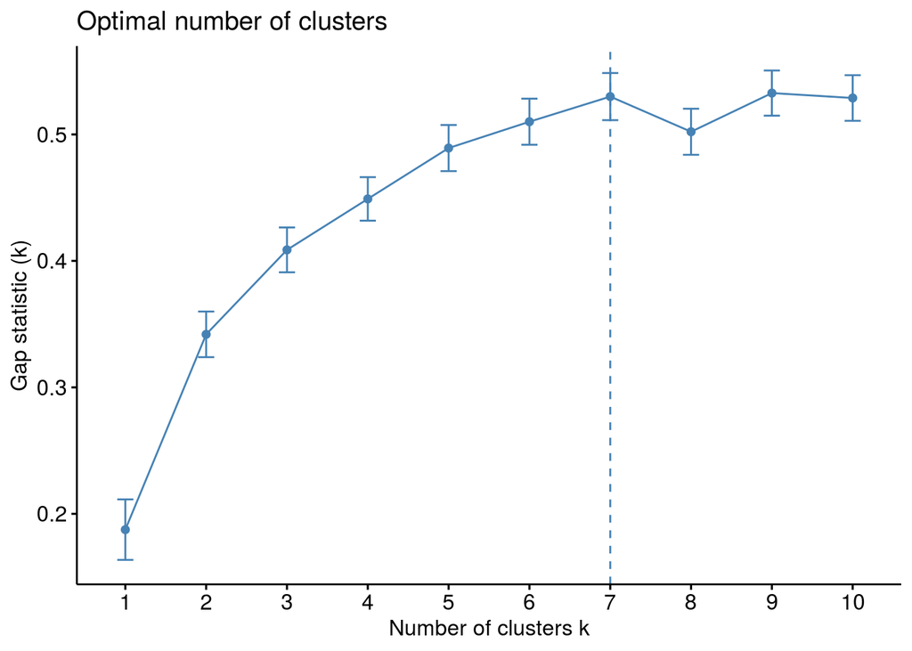

```r
fviz_nbclust(inputData, pam,diss=g.dist,method = "gap_stat",k.max = 10,verbose = F)
```

- Clusters recomendados para jerarquización:

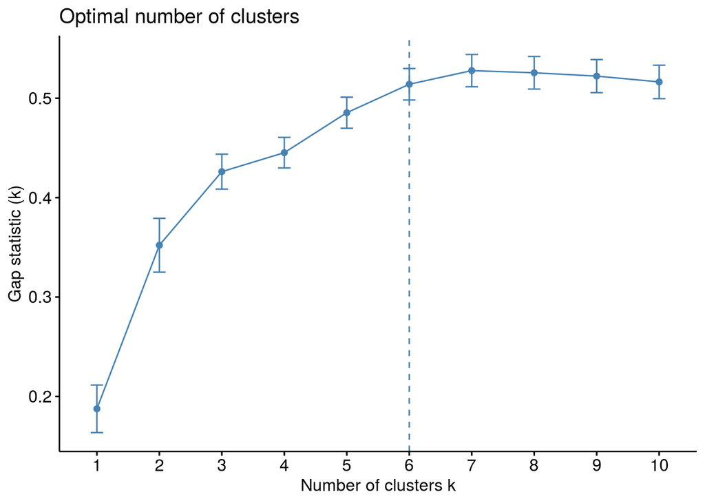

```r
fviz_nbclust(inputData, hcut,diss=g.dist,method = "gap_stat",k.max = 10,verbose = F)
```

```r
pam.resultado7=pam(g.dist,7,cluster.only = F)
pam.resultado6=pam(g.dist,6,cluster.only = F)

res.agnes<- hcut(g.dist, k = 6,hc_func='agnes',hc_method = "ward.D")
res.diana <- hcut(g.dist, k = 6,hc_func='diana')
```

```
##   cluster size ave.sil.width
## 1       1   14          0.56
## 2       2   29          0.25
## 3       3   31          0.34
## 4       4   33          0.09
## 5       5   25          0.24
## 6       6   19          0.27
## 7       7   16          0.27
```

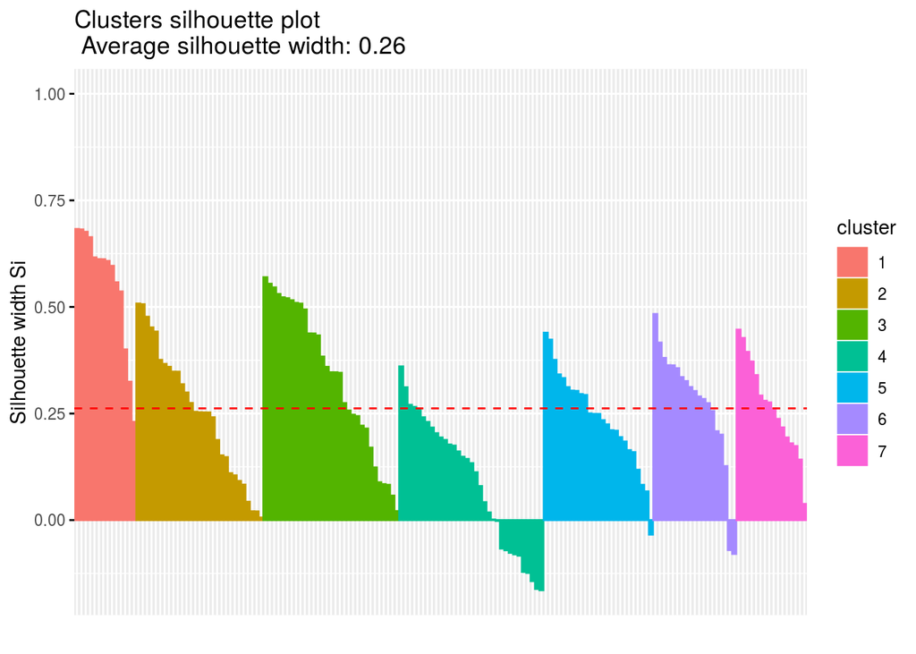

```r
fviz_silhouette(pam.resultado7)
```

```r
silPAM7 <- pam.resultado7$silinfo$widths
neg_sil7 <- which(silPAM7[, 'sil_width'] < 0)
silPAM7[neg_sil7,];length(neg_sil7)
```

```
##                  cluster neighbor    sil_width
## Senegal                4        3 -0.001996945
## Sri Lanka              4        3 -0.066685514
## Indonesia              4        3 -0.070726891
## Papua New Guinea       4        3 -0.076690403
## Bhutan                 4        3 -0.080388502
## Bangladesh             4        3 -0.083456010
## Guatemala              4        3 -0.121607271
## Hong Kong              4        2 -0.123919892
## Montenegro             4        3 -0.143126895
## Honduras               4        3 -0.161427032
## Namibia                4        3 -0.164393554
## Angola                 5        6 -0.034037577
## Myanmar                6        5 -0.070283467
## Burundi                6        7 -0.079293731
```

```
## [1] 14
```

```
##   cluster size ave.sil.width
## 1       1   14          0.56
## 2       2   29          0.25
## 3       3   31          0.34
## 4       4   35          0.09
## 5       5   32          0.26
## 6       6   26          0.28
```

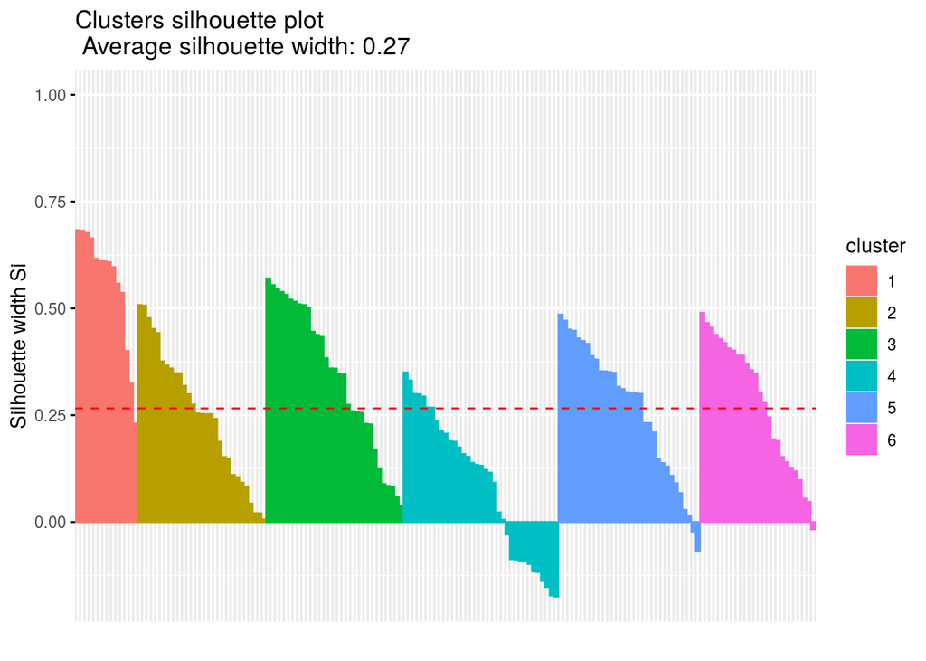

```r
fviz_silhouette(pam.resultado6)
```

```r
silPAM6 <- pam.resultado6$silinfo$widths
neg_sil6 <- which(silPAM6[, 'sil_width'] < 0)
silPAM6[neg_sil6,];length(neg_sil6)
```

```
##                  cluster neighbor   sil_width
## Senegal                4        3 -0.02924820
## Bhutan                 4        3 -0.08703448
## Sri Lanka              4        3 -0.08783175
## Indonesia              4        3 -0.09030561
## Bangladesh             4        3 -0.09230408
## Papua New Guinea       4        3 -0.09849960
## Turkey                 4        5 -0.11586796
## Hong Kong              4        2 -0.11739495
## Guatemala              4        3 -0.13808685
## Montenegro             4        3 -0.15228868
## Honduras               4        3 -0.17196624
## Namibia                4        3 -0.17448713
## Belarus                5        6 -0.02223541
## Eswatini               5        6 -0.06773460
## Ethiopia               6        5 -0.01692285
```

```
## [1] 15
```

```r
intersect(names(neg_sil6),names(neg_sil7))
```

```
##  [1] "Senegal"          "Bhutan"           "Sri Lanka"
##  [4] "Indonesia"        "Bangladesh"       "Papua New Guinea"
##  [7] "Hong Kong"        "Guatemala"        "Montenegro"
## [10] "Honduras"         "Namibia"
```

```r
setdiff(names(neg_sil6),names(neg_sil7))
```

```
## [1] "Turkey"   "Belarus"  "Eswatini" "Ethiopia"
```

```r
setdiff(names(neg_sil7),names(neg_sil6))
```

```
## [1] "Angola"  "Myanmar" "Burundi"
```

```
##   cluster size ave.sil.width
## 1       1   14          0.57
## 2       2   33          0.26
## 3       3   34          0.25
## 4       4   34          0.08
## 5       5   19          0.34
## 6       6   33          0.25
```

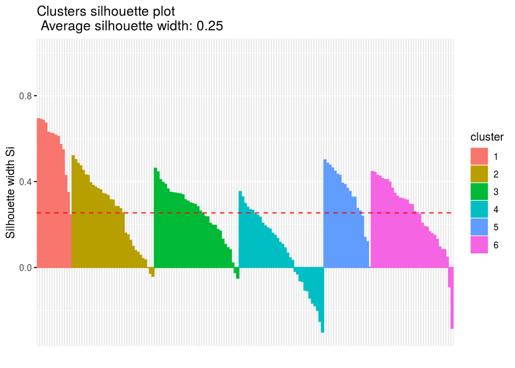

```r
fviz_silhouette(res.agnes)
```

```r
silAg <- res.agnes$silinfo$widths
neg_silAg <- which(silAg[, 'sil_width'] < 0)
silAg[neg_silAg,];length(neg_silAg)
```

```
##              cluster neighbor    sil_width
## Uruguay            2        1 -0.000219396
## Mauritius          2        1 -0.027307230
## South Africa       2        3 -0.040886045
## Malaysia           3        2 -0.023572839
## Hong Kong          3        2 -0.049805613
## Bhutan             4        3 -0.017806291
## Benin              4        3 -0.030093449
## Georgia            4        3 -0.061717649
## Ivory Coast        4        5 -0.065290150
## Bangladesh         4        3 -0.105427873
## Fiji               4        3 -0.108703477
## Honduras           4        3 -0.142746467
## Myanmar            4        5 -0.166071513
## Guatemala          4        3 -0.178035442
## Niger              4        5 -0.199509449
## Jordan             4        5 -0.251009228
## Kuwait             4        5 -0.300952247
## Zimbabwe           6        5 -0.089883700
## Angola             6        5 -0.283026558
```

```
## [1] 19
```

```
##   cluster size ave.sil.width
## 1       1   39          0.47
## 2       2   52          0.27
## 3       3    3          0.25
## 4       4   38          0.10
## 5       5   18          0.34
## 6       6   17          0.25
```

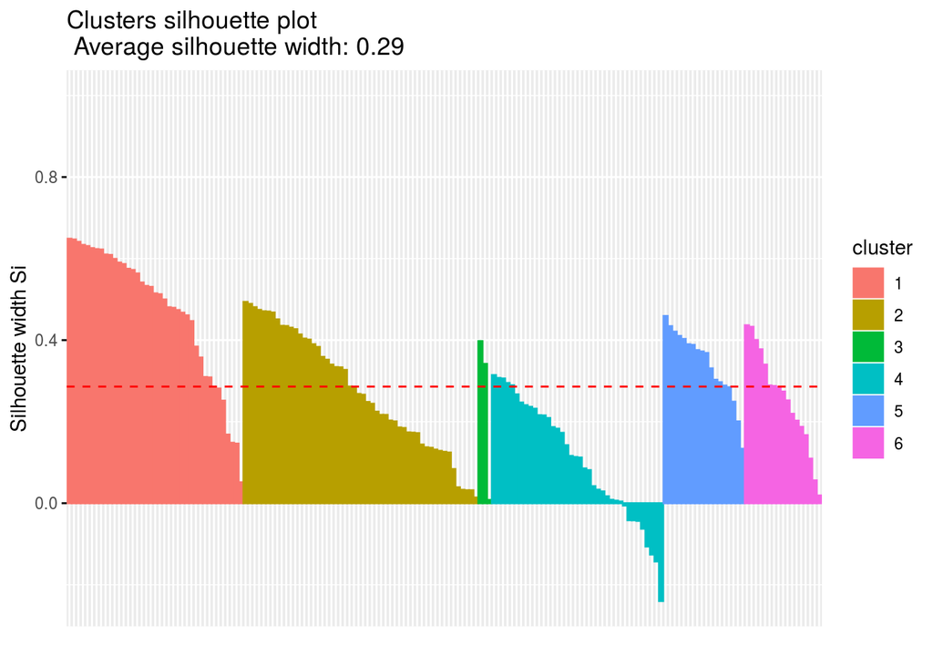

```r
fviz_silhouette(res.diana)
```

```r
silDi <- res.diana$silinfo$widths
neg_silDi <- which(silDi[, 'sil_width'] < 0)
silDi[neg_silDi,];length(neg_silDi)
```

```
##                        cluster neighbor    sil_width
## Armenia                      4        2 -0.005687722
## Myanmar                      4        5 -0.041697269
## Russia                       4        5 -0.041898397
## Algeria                      4        5 -0.043388369
## Bosnia and Herzegovina       4        2 -0.062495534
## Kenya                        4        3 -0.106181352
## Cameroon                     4        5 -0.125828661
## Nepal                        4        3 -0.142860221
## Angola                       4        5 -0.239925302
```

```
## [1] 9
```

La estrategia basada en densidad sigue una estrategia muy sencilla: juntar a los casos cuya cercanía entre sí los diferencia de otros. Aquí hay un resumen breve del tema:

[video not shown]

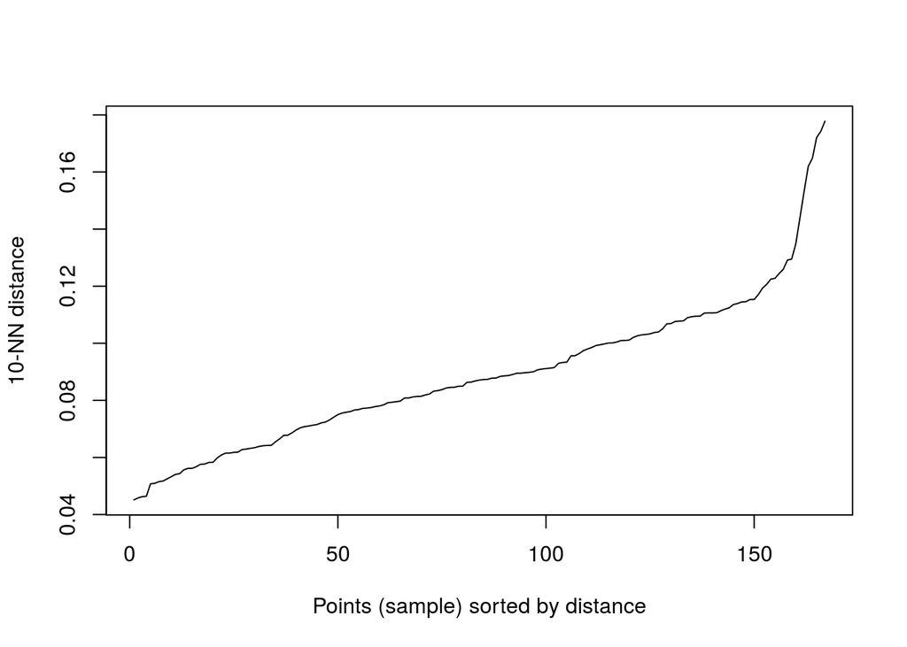

```r
library(dbscan)
kNNdistplot(g.dist, k=10)
```

```r
library(fpc)
db.res = dbscan(g.dist, eps=.15, MinPts=10,method = 'dist');  db.res
```

```
## dbscan Pts=167 MinPts=10 eps=0.15
##          1
## border   5
## seed   162
## total  167
```

```r
table(db.res$cluster)
```

```
##
##   1
## 167
```

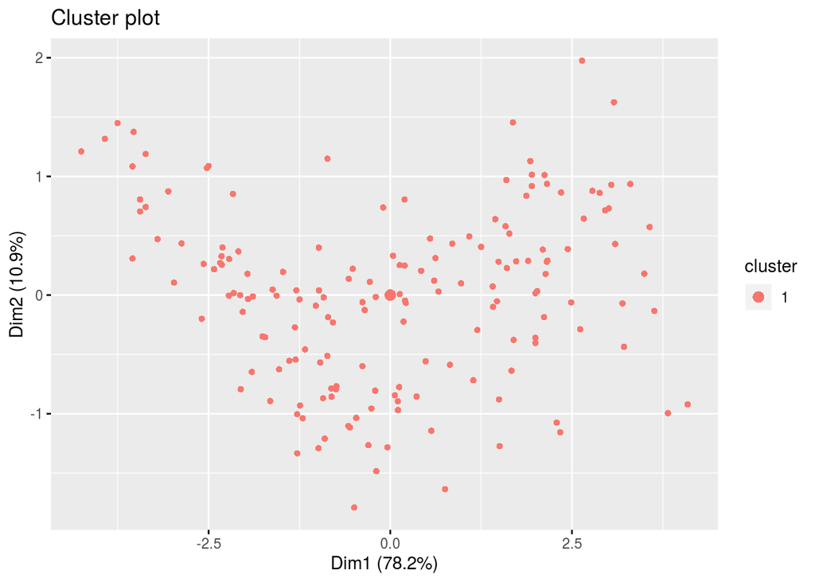

```r
factoextra::fviz_cluster(db.res,data = inputData, ellipse = F,geom = 'point')
```

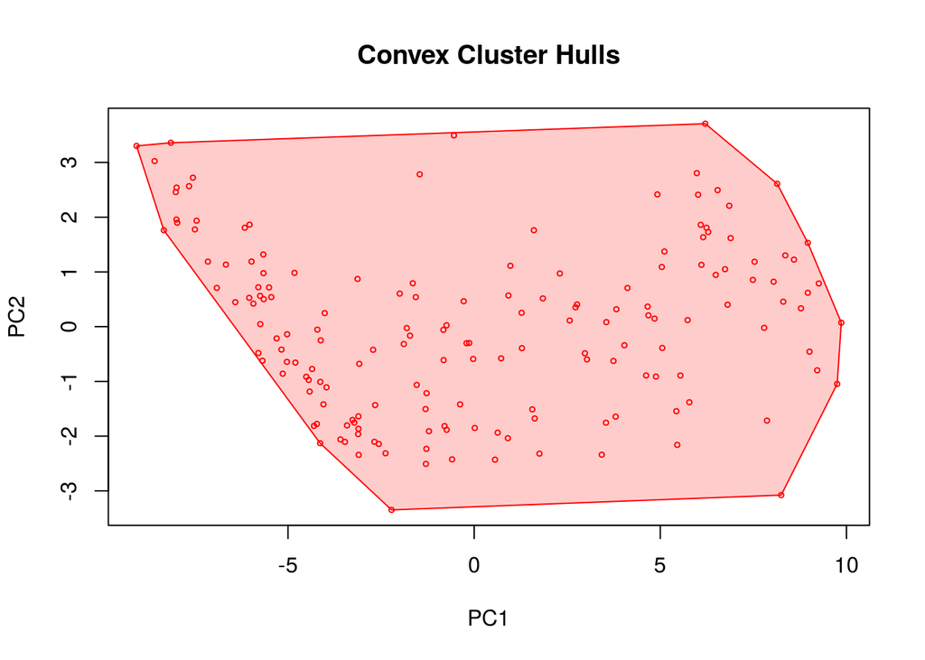

```r
hullplot(inputData,db.res$cluster)
```

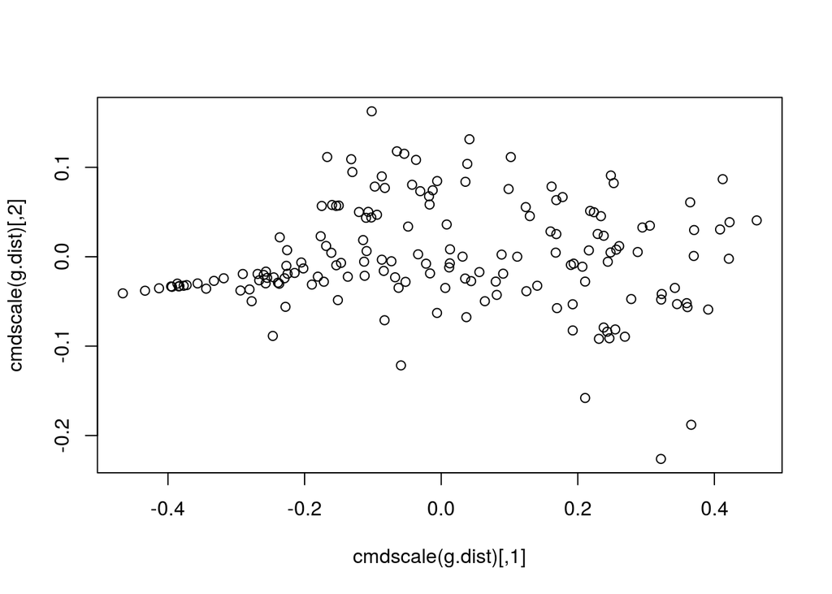

```r
plot(cmdscale(g.dist))
```

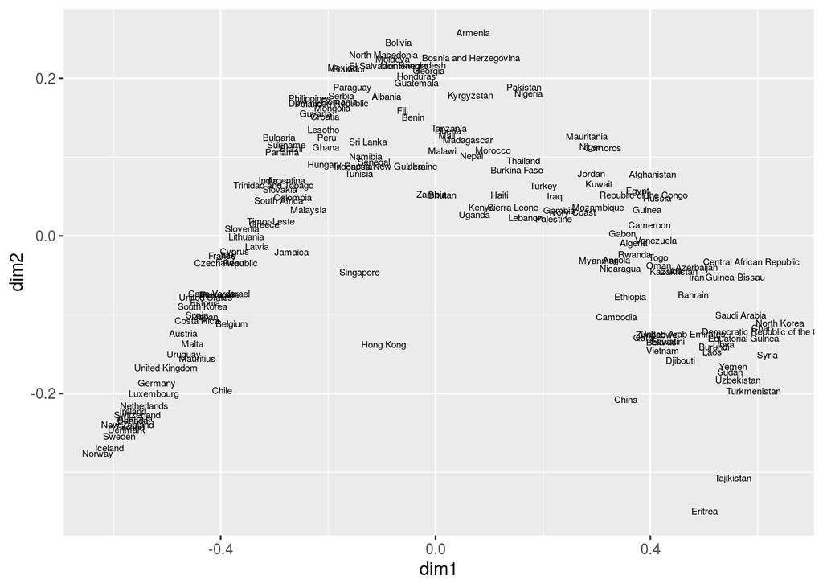

```r
result <- cmdscale(g.dist,eig=TRUE, k=2,add = T) # k is the number of dim

# data frame prep:
inputData$dim1 <- result$points[,1]
inputData$dim2 <- result$points[,2]


base= ggplot(inputData,aes(x=dim1, y=dim2,label=row.names(inputData)))
base + geom_text(size=2)
```

```r
g.dist.cmd = daisy(inputData[,c('dim1','dim2')], metric = 'euclidean')
pam.cmd=pam(g.dist.cmd,6,cluster.only = F)
agnes.cmd<- hcut(g.dist.cmd, k = 6,hc_func='agnes',hc_method = "ward.D")
diana.cmd <- hcut(g.dist.cmd, k = 6,hc_func='diana')
```

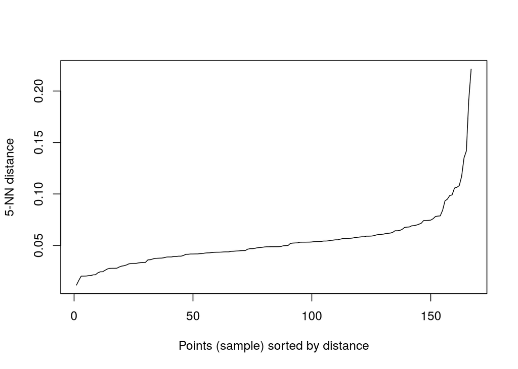

```r
kNNdistplot(g.dist.cmd, k=5)
```

```r
library(fpc)
db.cmd = dbscan(g.dist.cmd, eps=.06, MinPts=5,method = 'dist');  db.cmd
```

```
## dbscan Pts=167 MinPts=5 eps=0.06
##         0  1  2  3
## border 11  2  0 12
## seed    0 49 33 60
## total  11 51 33 72
```

```r
inputData$pamCMD=as.factor(pam.cmd$clustering)
inputData$agnesCMD=as.factor(agnes.cmd$cluster)
inputData$dianaCMD=as.factor(diana.cmd$cluster)
inputData$dbCMD=as.factor(db.cmd$cluster)
```

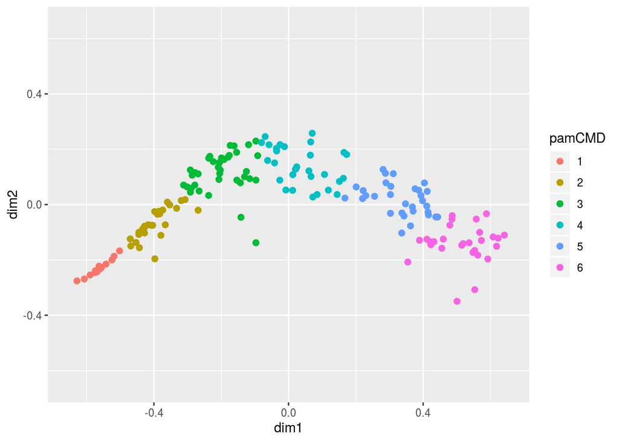

```r
limites=c(-0.65,0.65)
base= ggplot(inputData,aes(x=dim1, y=dim2,label=row.names(inputData)))
base + geom_point(size=2, aes(color=pamCMD)) + ylim(limites) + xlim(limites)
```

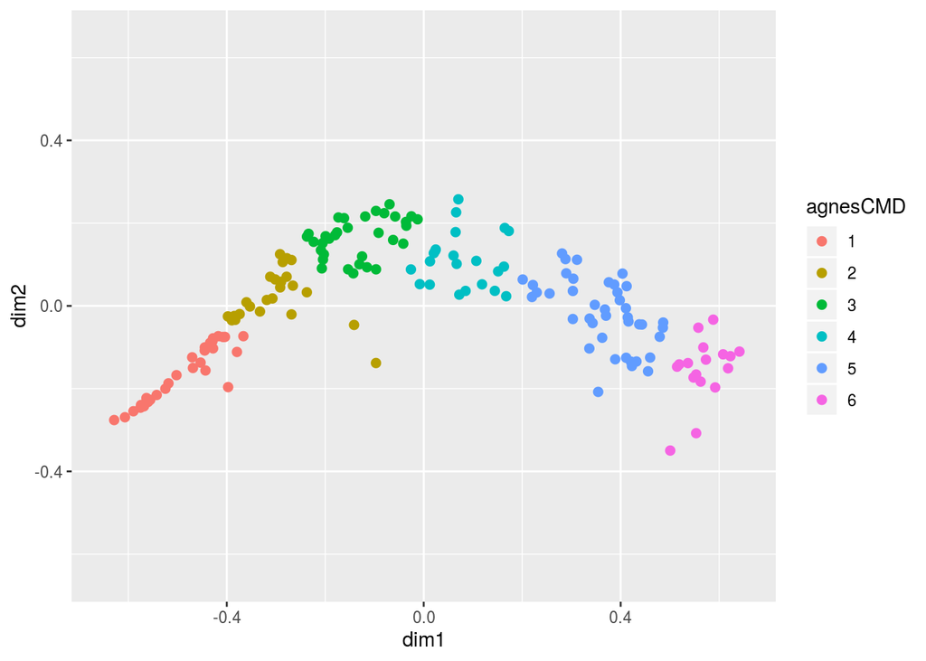

```r
base + geom_point(size=2, aes(color=agnesCMD)) + ylim(limites) + xlim(limites)
```

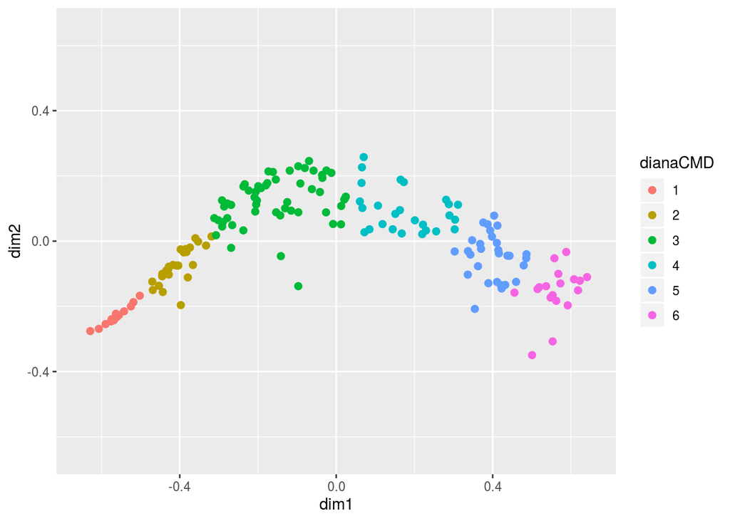

```r
base + geom_point(size=2, aes(color=dianaCMD)) + ylim(limites) + xlim(limites)
```

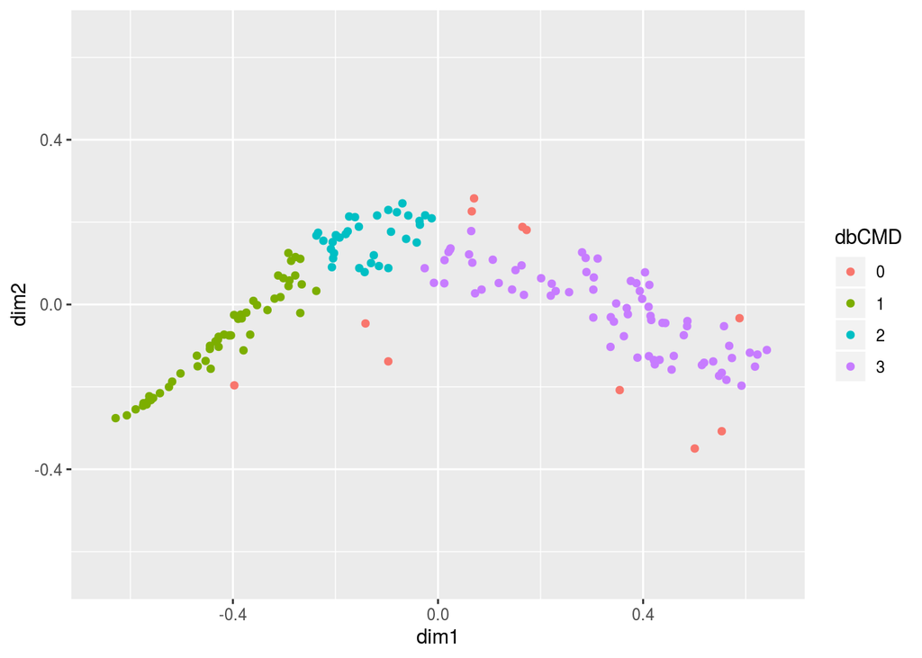

```r
library(ggrepel)

dbplot= base + geom_point(aes(color=dbCMD))  + ylim(limites) + xlim(limites)
dbplot
```

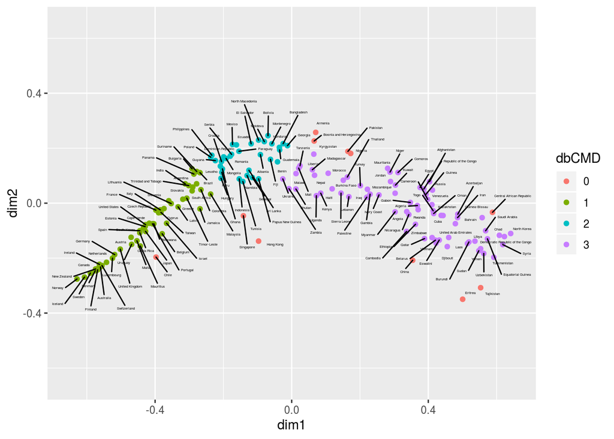

```r
dbplot + geom_text_repel(size=1)
```

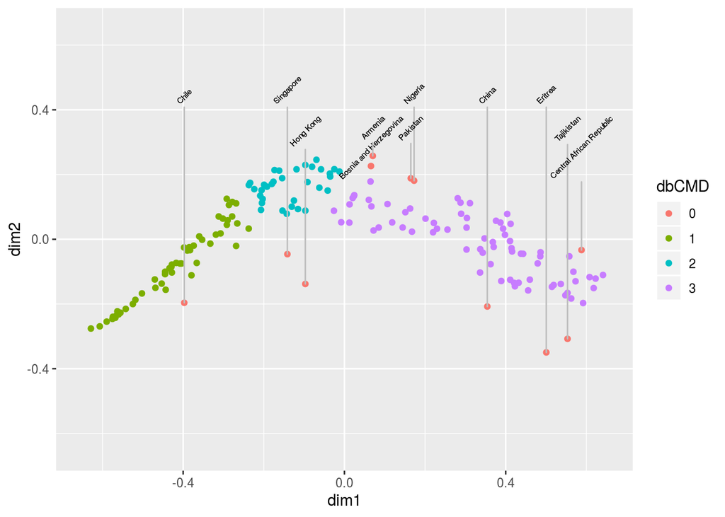

```r
LABEL=ifelse(inputData$dbCMD==0,row.names(inputData),"")
dbplot + geom_text_repel(aes(label=LABEL),
                         size=2,
                         direction = "y", ylim = 0.4,
                         angle=45,
                         segment.colour = "grey")
```